# Chapter 03 Data Visualization

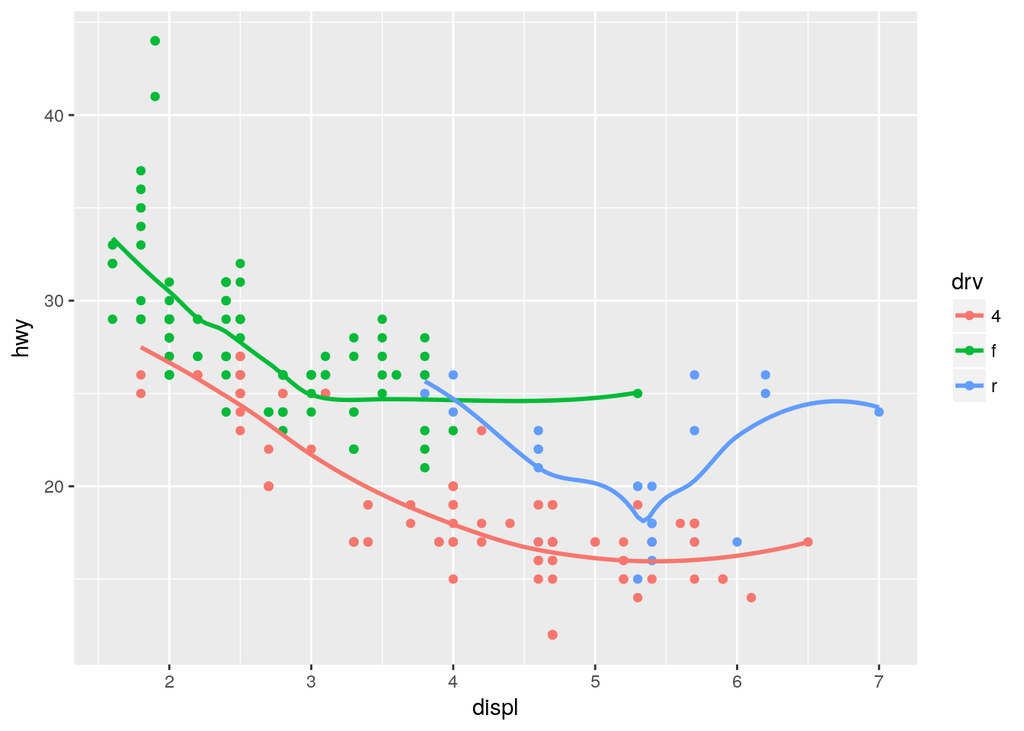

   ```r
   ggplot(data = mpg, mapping = aes(x = displ, y = hwy, color = drv)) +
     geom_point() +
     geom_smooth(se = FALSE)
   ```

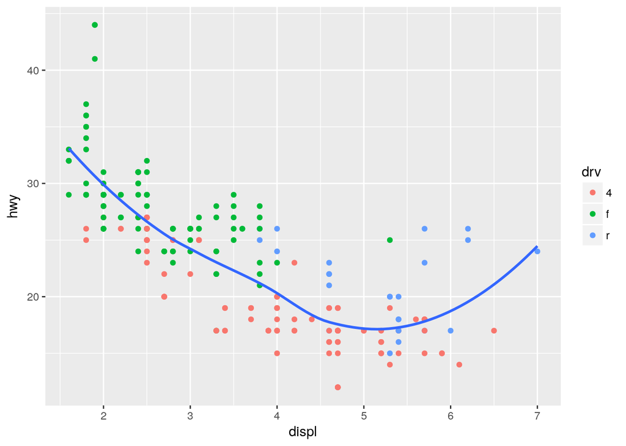

   ```r
   ggplot(data = mpg, mapping = aes(x = displ, y = hwy)) +
     geom_point(aes(color = drv)) +
     geom_smooth(se = FALSE)
   ```

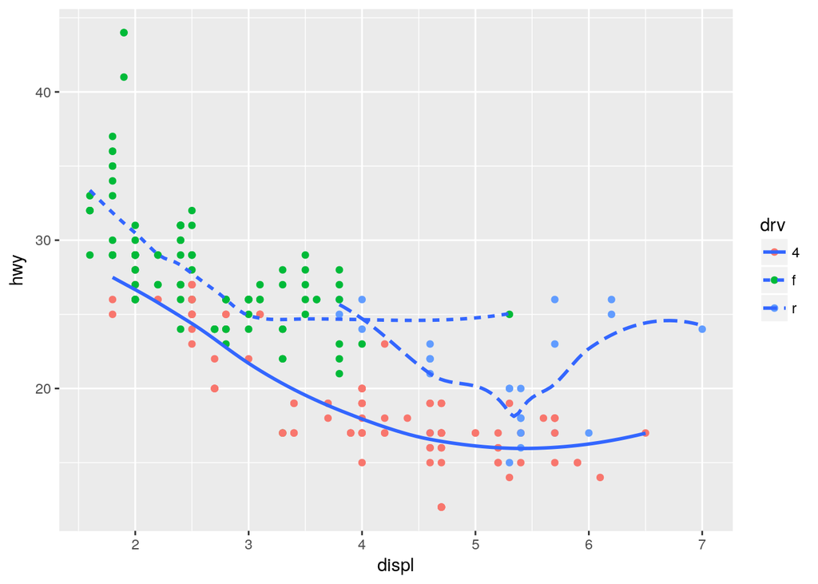

   ```r
   ggplot(data = mpg, mapping = aes(x = displ, y = hwy)) +
     geom_point(aes(color = drv)) +
     geom_smooth(se = FALSE, aes(linetype = drv))
   ```

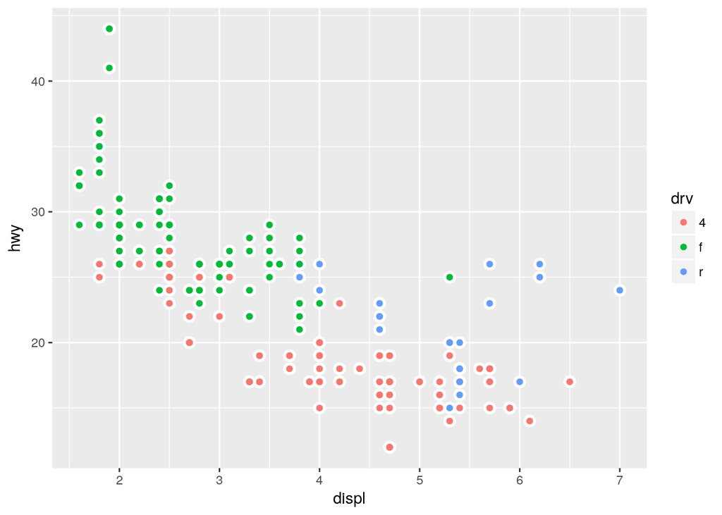

   ```r
   ggplot(data = mpg, mapping = aes(x = displ, y = hwy, color = drv)) +
     geom_point(stroke = 2, color = "white") +
     geom_point()
   ```

## Statistical transformations

### Content

Specify the stat in the plotting function like this:

```r
ggplot(data = demo) +
  geom_bar(mapping = aes(x = a, y = b), stat = "identity")
```

### Exercises

1. What is the default geom associated with `stat_summary()`? How could you rewrite the previous plot to use that geom function instead of the stat function?

   The `stat_summary()` function uses `geom = "pointrange"` by default.

   Previous plot:

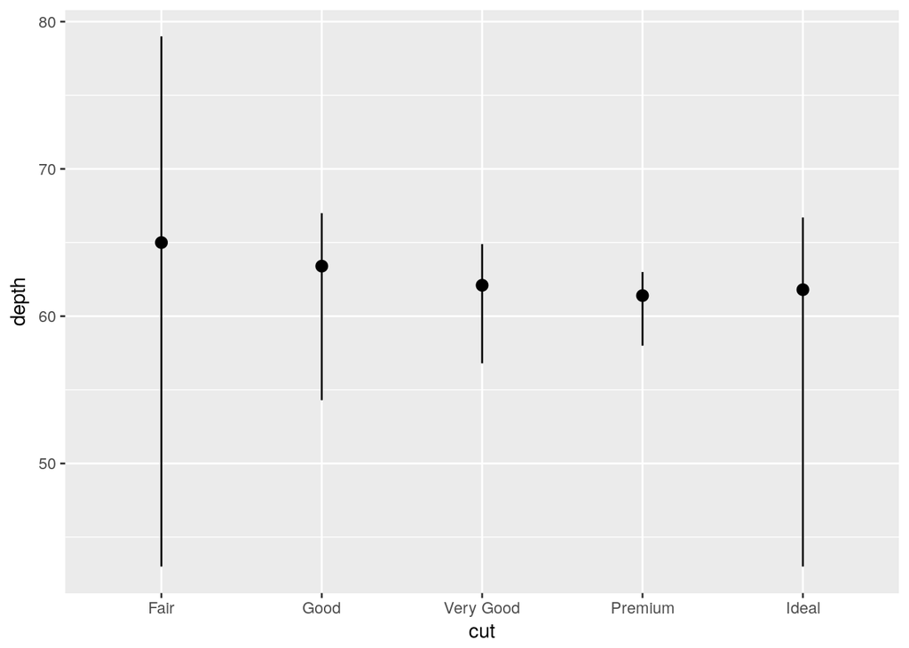

   ```r
   ggplot(diamonds, aes(x = cut, y = depth)) +
     stat_summary(
       fun.ymin = min,
       fun.ymax = max,
       fun.y = median
     )
   ```

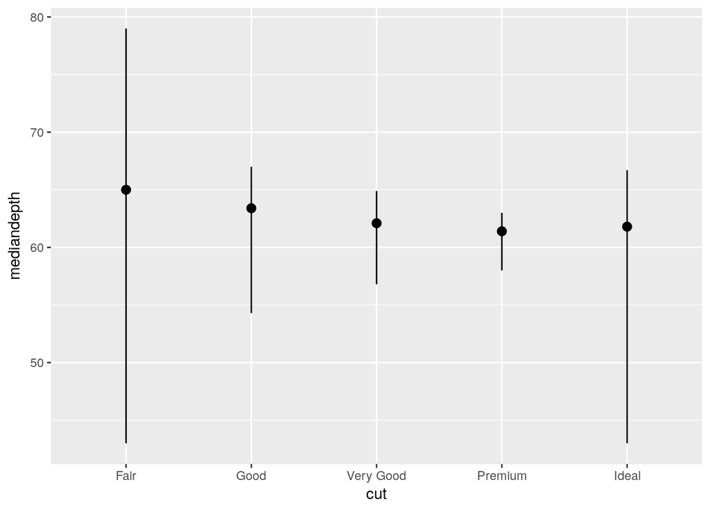

   ```r
   diamonds %>%
     select(cut, depth) %>%
     group_by(cut) %>%
     summarize(mindepth = min(depth), maxdepth = max(depth), mediandepth = median(depth)) %>%
     ggplot(aes(x = cut, y = mediandepth, ymin = mindepth, ymax = maxdepth)) +
     geom_pointrange()
   ```

2. What does `geom_col()` do? How is it different to `geom_bar()`?

   ```r
   ?geom_bar()
   ```

   > `geom_bar` makes the height of the bar proportional to the number of cases in each group […]. If you want the heights of the bars to represent values in the data, use `geom_col` instead. `geom_bar` uses `stat_count` by default […]. `geom_col` uses `stat_identity`.
3. Most geoms and stats come in pairs that are almost always used in concert. Read through the documentation and make a list of all the pairs. What do they have in common?

   http://docs.ggplot2.org/current/index.html: see stats for each geom
4. What variables does `stat_smooth()` compute? What parameters control its behaviour?

   `stat_smooth` uses the same arguments as `geom_smooth` but can be used whenever a non-standard geom should be plotted. It computes a regression line and standard error bounds. It is possible to specify:
   - `method`: the smoothing method
   - `formula`: the regression formula to be used
   - `se`: whether to display a confidence interval around the smoothed regression line
   - etc (read documentation)
5. In our proportion bar chart, we need to set `group = 1`. Why? In other words what is the problem with these two graphs?

   `group = 1` specifies that all values should be put into one grouping. This is necessary for the values to be in proportion to the whole population as opposed to just their own group. Without grouping, R computes the values in the plot as follows: fair is 100% of fair, good is 100% of good If the option is set, R computes them like this: fair is 3% of the whole sample, good is 9% etc.

## Position adjustments

### Content

### Exercises

1. What is the problem with this plot? How could you improve it?

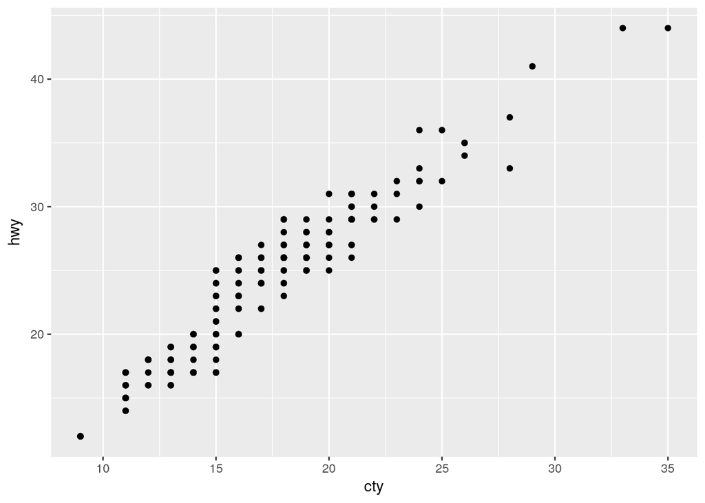

   ```r
   ggplot(data = mpg, mapping = aes(x = cty, y = hwy)) +
     geom_point()
   ```

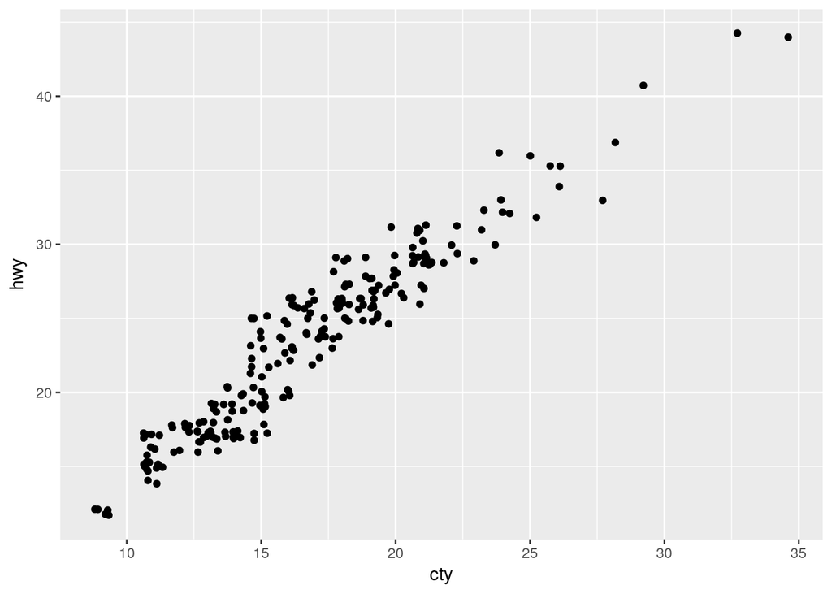

   ```r
   ggplot(data = mpg, mapping = aes(x = cty, y = hwy)) +
     geom_point(position = "jitter")
   ```

   In order to get a feeling for how many points cluster at each spot it is helpful to either use jitter, which moves the points by a random amount in height and width, or opacity.
2. What parameters to `geom_jitter()` control the amount of jittering?

   `width` and `height` and be set to percentage values with a default of 40% each.
3. Compare and contrast `geom_jitter()` with `geom_count()`.

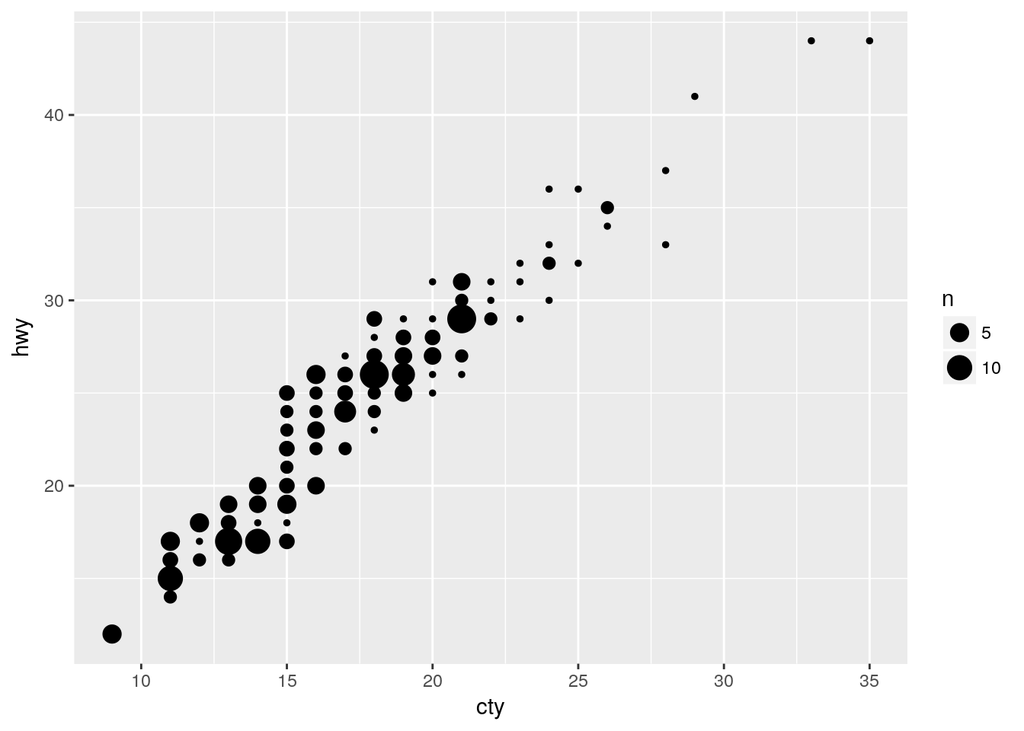

   ```r
   ggplot(data = mpg, mapping = aes(x = cty, y = hwy)) +
   geom_count()
   ```

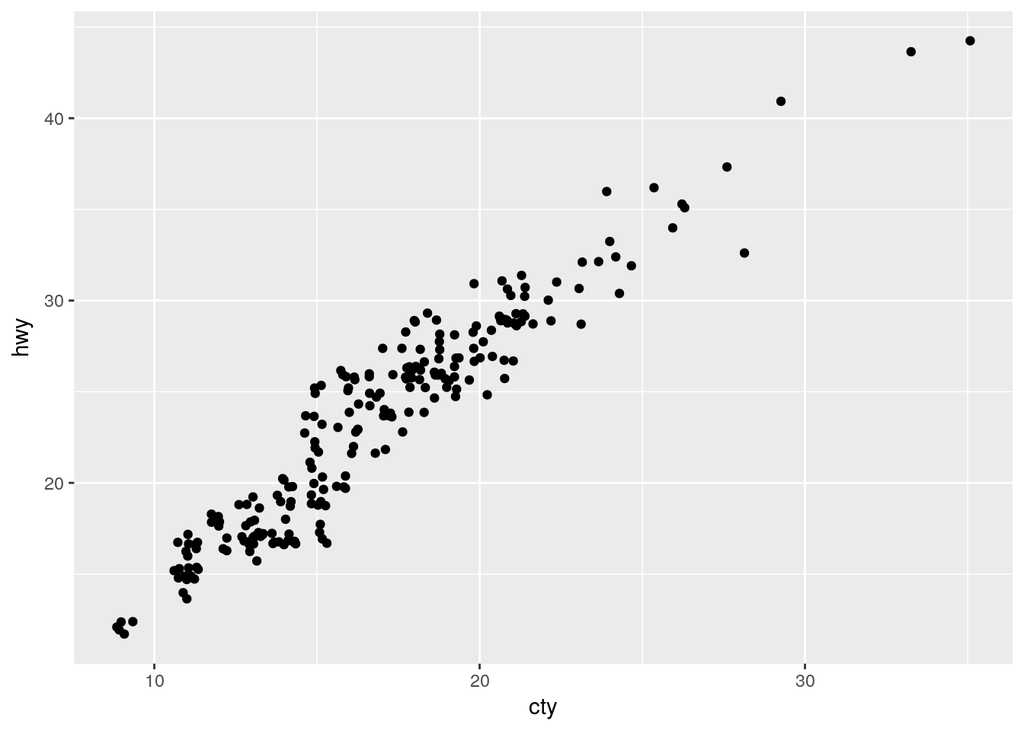

   ```r
   ggplot(data = mpg, mapping = aes(x = cty, y = hwy)) +
   geom_jitter()
   ```

   `geom_count()` counts the number of observations that occur at each point in the coordinate system. The higher that number, the bigger the point in the point chart.

   `geom_jitter()` moves the points instead, so that areas with more observations are visibly denser than others.
4. What’s the default position adjustment for `geom_boxplot()`? Create a visualisation of the `mpg` dataset that demonstrates it.

   The default setting for `geom_boxplot()` is `position = "dodge"`.

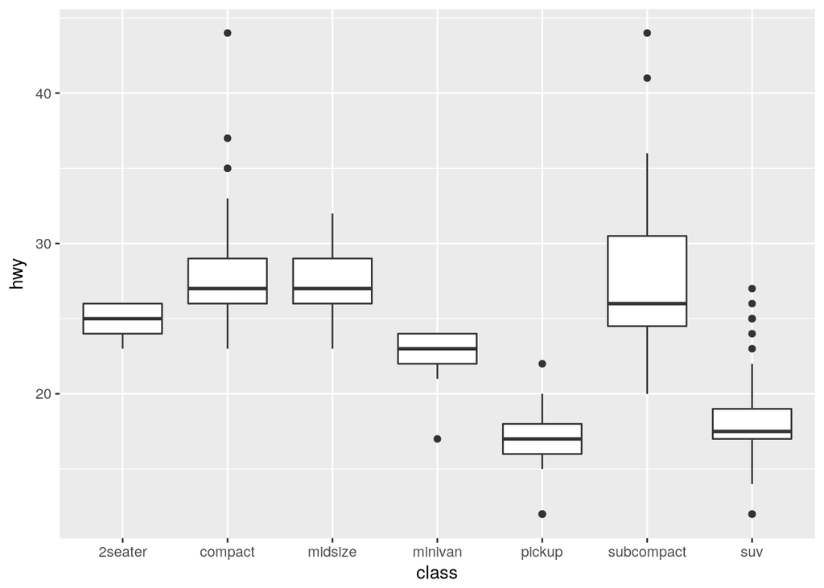

   ```r
   ggplot(mpg, aes(x = class, y = hwy)) +
     geom_boxplot()
   ```

   This means that next to each boxplot, there is some space to the side until the next one follows.

## Coordinate systems

### Content

### Exercises

1. Turn a stacked bar chart into a pie chart using `coord_polar()`.

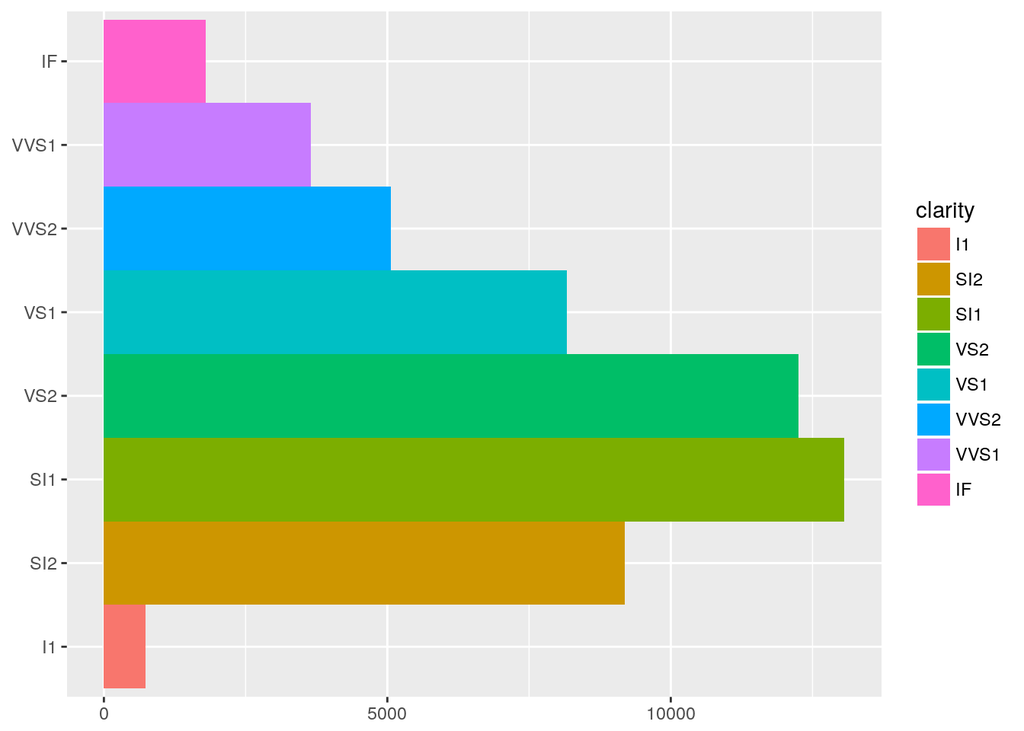

   ```r
   plot <- ggplot(diamonds) +
     geom_bar(aes(x = clarity, fill = clarity), width = 1) +
     labs(x = NULL, y = NULL) +
     coord_flip()
   plot
   ```

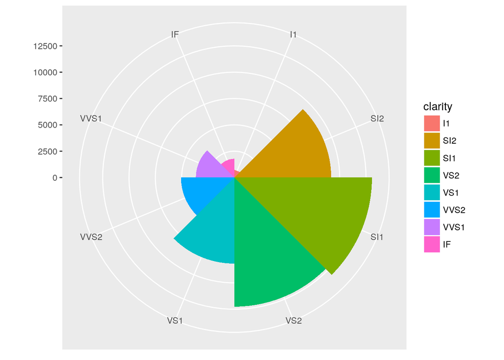

   ```r
   plot + coord_polar()
   ```

2. What does `labs()` do? Read the documentation.

   `labs()` sets the axis labels
3. What’s the difference between `coord_quickmap()` and `coord_map()`? `coord_quickmap` preserves straight lines in order to save computation time and is just an approximation of a map projection.
4. What does the plot below tell you about the relationship between city and highway mpg? Why is `coord_fixed()` important? What does `geom_abline()` do?

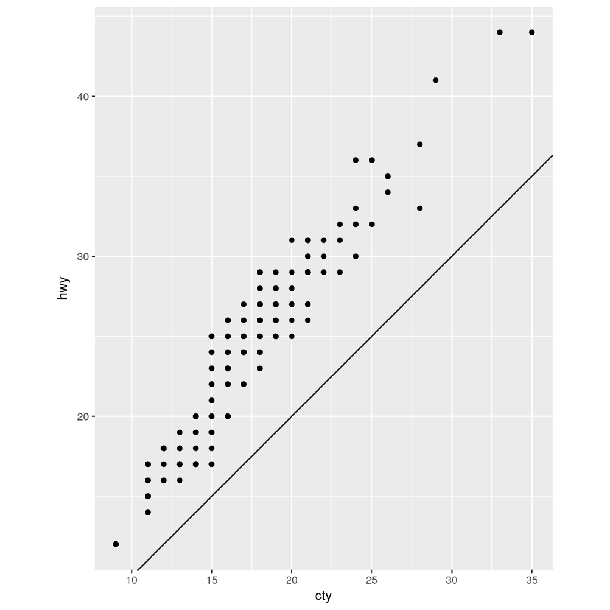

   ```r
   ggplot(data = mpg, mapping = aes(x = cty, y = hwy)) +
     geom_point() +
     geom_abline() +
     coord_fixed()
   ```

## The layered grammar of graphics